# Wind Power Lookup: Wind1 & Wind2

Erick Chauke

Same approach as `02_pv_power_lookup.ipynb`, applied to the two wind plants: a heatmap, a 3D view, the lookup table itself, and a nearest-measurement lookup function, no fitting anywhere. The one difference from PV: wind direction is circular (15 deg and 360 deg are neighboring bearings, not far apart), so the lookup treats the direction axis that way when finding the closest measurement.

## Setup

```python
import sys
sys.path.insert(0, "../src")

import numpy as np
import pandas as pd
import matplotlib.pyplot as plt
from mpl_toolkits.mplot3d import Axes3D  # enables the 3D plot below
from grid_lookup import parse_grid_sheet, grid_to_table, nearest_lookup

DATA_PATH = "../data/FPCs.xlsm"
CAPACITY_MW = {"Wind1": 102.0, "Wind2": 86.6}
```

## Wind1

```python
_, x_axis_wind1, y_axis_wind1, grid_wind1 = parse_grid_sheet(DATA_PATH, "Wind1")
if "Wind1" == "Wind2":
    # Clip the documented near-zero negative artifact (measurement noise around zero wind
    # speed, not real negative generation, see 01_data_exploration.ipynb).
    grid_wind1 = np.clip(grid_wind1, 0.0, None)
table_wind1 = grid_to_table(x_axis_wind1, y_axis_wind1, grid_wind1, "wind_direction", "wind_velocity")
print(f"Wind1: {len(table_wind1)} measured cells out of {grid_wind1.size}")
```

```
Wind1: 1224 measured cells out of 1224
```

### Heatmap

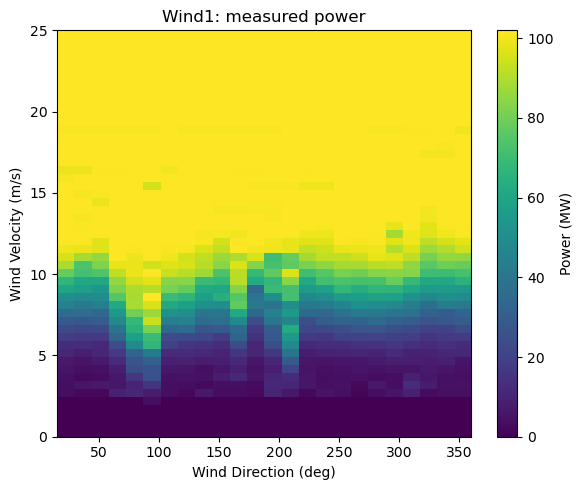

```python
fig, ax = plt.subplots(figsize=(6, 5))
im = ax.imshow(
    grid_wind1, origin="lower", aspect="auto",
    extent=[x_axis_wind1.min(), x_axis_wind1.max(), y_axis_wind1.min(), y_axis_wind1.max()],
    vmin=0, vmax=CAPACITY_MW["Wind1"],
)
ax.set_xlabel("Wind Direction (deg)")
ax.set_ylabel("Wind Velocity (m/s)")
ax.set_title("Wind1: measured power")
fig.colorbar(im, ax=ax, label="Power (MW)")
fig.tight_layout()
fig.savefig("../outputs/wind1_heatmap.png", dpi=150)
plt.show()
```

### 3D View

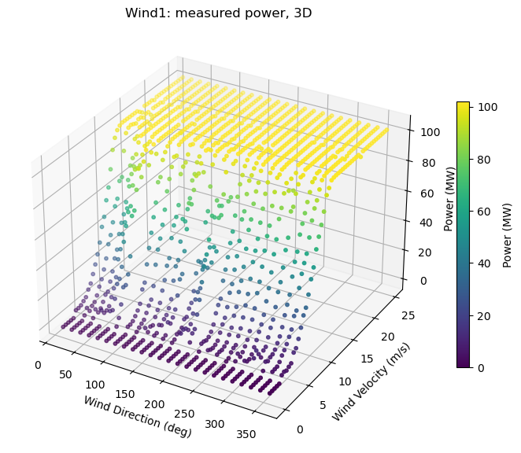

```python
fig = plt.figure(figsize=(7, 6))
ax = fig.add_subplot(111, projection="3d")
scatter = ax.scatter(table_wind1["wind_direction"], table_wind1["wind_velocity"], table_wind1["power"],
                      c=table_wind1["power"], cmap="viridis", s=10)
ax.set_xlabel("Wind Direction (deg)")
ax.set_ylabel("Wind Velocity (m/s)")
ax.set_zlabel("Power (MW)")
ax.set_title("Wind1: measured power, 3D")
fig.colorbar(scatter, ax=ax, label="Power (MW)", shrink=0.6)
fig.tight_layout()
fig.savefig("../outputs/wind1_3d_surface.png", dpi=150)
plt.show()
```

### The Lookup Table

One row per measured (velocity, direction) combination. The grid here is fully dense, so unlike PV there are no missing combinations to worry about.

```python
print(table_wind1.sort_values(["wind_velocity", "wind_direction"]).head(10).to_string(index=False))
print(f"... {len(table_wind1) - 10} more rows")
```

```
 wind_velocity  wind_direction  power
           0.0            15.0    0.0
           0.0            30.0    0.0
           0.0            45.0    0.0
           0.0            60.0    0.0
           0.0            75.0    0.0
           0.0            90.0    0.0
           0.0           105.0    0.0
           0.0           120.0    0.0
           0.0           135.0    0.0
           0.0           150.0    0.0
... 1214 more rows
```

### Looking Up a Value

The direction axis wraps around (360 deg is next to 15 deg, not far from it), so the lookup measures direction distance the short way around the compass, not by plain subtraction.

```python
sample_queries_wind1 = [(10, 180), (7.3, 95), (18, 358)]
for velocity_query, direction_query in sample_queries_wind1:
    result = nearest_lookup(table_wind1, "wind_direction", "wind_velocity",
                             x_query=direction_query, y_query=velocity_query, circular_x=True)
    print(f"Query: velocity={velocity_query} m/s, direction={direction_query} deg  ->  "
          f"closest measurement: velocity={result['wind_velocity']:.1f}, "
          f"direction={result['wind_direction']:.0f}, power={result['power']:.2f} MW")
```

```
Query: velocity=10 m/s, direction=180 deg  ->  closest measurement: velocity=10.0, direction=180, power=68.35 MW
Query: velocity=7.3 m/s, direction=95 deg  ->  closest measurement: velocity=7.5, direction=90, power=87.13 MW
Query: velocity=18 m/s, direction=358 deg  ->  closest measurement: velocity=18.0, direction=360, power=102.00 MW
```

## Wind2

```python
_, x_axis_wind2, y_axis_wind2, grid_wind2 = parse_grid_sheet(DATA_PATH, "Wind2")
if "Wind2" == "Wind2":
    # Clip the documented near-zero negative artifact (measurement noise around zero wind
    # speed, not real negative generation, see 01_data_exploration.ipynb).
    grid_wind2 = np.clip(grid_wind2, 0.0, None)
table_wind2 = grid_to_table(x_axis_wind2, y_axis_wind2, grid_wind2, "wind_direction", "wind_velocity")
print(f"Wind2: {len(table_wind2)} measured cells out of {grid_wind2.size}")
```

```
Wind2: 1224 measured cells out of 1224
```

### Heatmap

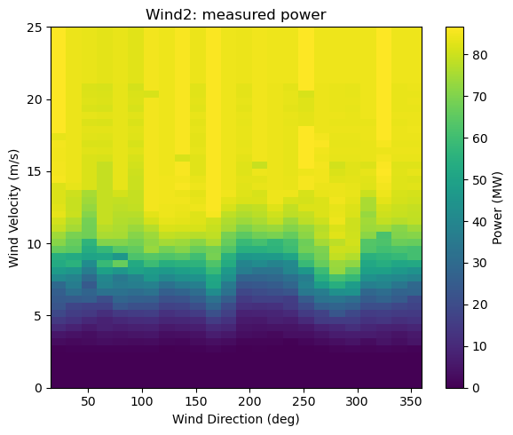

```python
fig, ax = plt.subplots(figsize=(6, 5))
im = ax.imshow(
    grid_wind2, origin="lower", aspect="auto",
    extent=[x_axis_wind2.min(), x_axis_wind2.max(), y_axis_wind2.min(), y_axis_wind2.max()],
    vmin=0, vmax=CAPACITY_MW["Wind2"],
)
ax.set_xlabel("Wind Direction (deg)")
ax.set_ylabel("Wind Velocity (m/s)")
ax.set_title("Wind2: measured power")
fig.colorbar(im, ax=ax, label="Power (MW)")
fig.tight_layout()
fig.savefig("../outputs/wind2_heatmap.png", dpi=150)
plt.show()
```

### 3D View

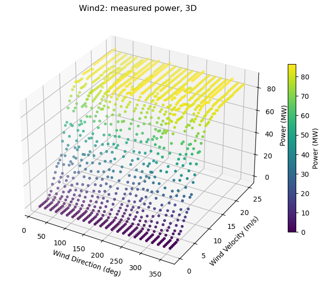

```python
fig = plt.figure(figsize=(7, 6))
ax = fig.add_subplot(111, projection="3d")
scatter = ax.scatter(table_wind2["wind_direction"], table_wind2["wind_velocity"], table_wind2["power"],
                      c=table_wind2["power"], cmap="viridis", s=10)
ax.set_xlabel("Wind Direction (deg)")
ax.set_ylabel("Wind Velocity (m/s)")
ax.set_zlabel("Power (MW)")
ax.set_title("Wind2: measured power, 3D")
fig.colorbar(scatter, ax=ax, label="Power (MW)", shrink=0.6)
fig.tight_layout()
fig.savefig("../outputs/wind2_3d_surface.png", dpi=150)
plt.show()
```

### The Lookup Table

One row per measured (velocity, direction) combination. The grid here is fully dense, so unlike PV there are no missing combinations to worry about.

```python
print(table_wind2.sort_values(["wind_velocity", "wind_direction"]).head(10).to_string(index=False))
print(f"... {len(table_wind2) - 10} more rows")
```

```
 wind_velocity  wind_direction  power
           0.0            15.0    0.0
           0.0            30.0    0.0
           0.0            45.0    0.0
           0.0            60.0    0.0
           0.0            75.0    0.0
           0.0            90.0    0.0
           0.0           105.0    0.0
           0.0           120.0    0.0
           0.0           135.0    0.0
           0.0           150.0    0.0
... 1214 more rows
```

### Looking Up a Value

The direction axis wraps around (360 deg is next to 15 deg, not far from it), so the lookup measures direction distance the short way around the compass, not by plain subtraction.

```python
sample_queries_wind2 = [(10, 180), (7.3, 95), (18, 358)]
for velocity_query, direction_query in sample_queries_wind2:
    result = nearest_lookup(table_wind2, "wind_direction", "wind_velocity",
                             x_query=direction_query, y_query=velocity_query, circular_x=True)
    print(f"Query: velocity={velocity_query} m/s, direction={direction_query} deg  ->  "
          f"closest measurement: velocity={result['wind_velocity']:.1f}, "
          f"direction={result['wind_direction']:.0f}, power={result['power']:.2f} MW")
```

```
Query: velocity=10 m/s, direction=180 deg  ->  closest measurement: velocity=10.0, direction=180, power=66.36 MW
Query: velocity=7.3 m/s, direction=95 deg  ->  closest measurement: velocity=7.5, direction=90, power=38.85 MW
Query: velocity=18 m/s, direction=358 deg  ->  closest measurement: velocity=18.0, direction=360, power=84.24 MW
```

## Why the Circular Handling Matters

A direction query of 358 degrees is genuinely close to both 360 and 15 on the compass. Measuring distance by plain subtraction would treat 358 as far from 15 (a difference of 343) and miss that they are actually neighbors, potentially matching the wrong measurement. The circular distance used above picks the shorter way around the circle instead, so a query near the 360/15 wrap-around point still finds its true nearest neighbor rather than one on the opposite side of the grid.